# Watershed Regression - Part 1: Linear Mixed Models (adapted to GLS Survival Analysis)

# Get Spatial data and merge

```r
#Spatial predcitors have been extracted and saved as a csv file.
#spatial_data<-read_csv("data/spatialPredictors_4_13.csv", col_types = cols(X1 = col_skip()))
spatial_data <- read_csv("data/spatialPredictors_5_14.csv")
#RES and COM are compositional data. Change to a ratio
spatial_data$LU_ratio = spatial_data$COM/spatial_data$RES
spatial_data <- dplyr::select(spatial_data, -c(RES,COM,.geo))
#merge spatial predictors with monitoring data
s8data.wPredictors <<- merge(s8data, spatial_data)%>%
  dplyr::select(-c(depSplusN))

kable(head(s8data.wPredictors),caption = "S8 Monitoring Data")
```

| Location | study_name | parameter | type | season | concentration | nondetect_flag | study_id | access_id | field_collection_end_date | field_collection_start_date | system:index | change_year_index | impervious | logPopulation | logTraffic | nighttime_lights | pm25 | roadDensity | soil | LU_ratio |
| --- | --- | --- | --- | --- | --- | --- | --- | --- | --- | --- | --- | --- | --- | --- | --- | --- | --- | --- | --- | --- |
| KICCOMS8D_OUT | King County Phase I Municipal Stormwater Permit | Copper - Water - Total | COM | 4 | 22.800 | FALSE | WAR044501_S8D | 36149 | 11/2/2011 | 11/2/2011 | 0000000000000000000e | -0.084 | -0.039 | -0.564 | -0.002 | -1.68 | -0.75 | 0.033 | -1.37 | -0.335 |
| KICCOMS8D_OUT | King County Phase I Municipal Stormwater Permit | LPAH - Water - Total | COM | 1 | 0.060 | FALSE | WAR044501_S8D | 102225 | NA | 2/12/2011 | 0000000000000000000e | -0.084 | -0.039 | -0.564 | -0.002 | -1.68 | -0.75 | 0.033 | -1.37 | -0.335 |
| KICCOMS8D_OUT | King County Phase I Municipal Stormwater Permit | Dichlobenil - Water - Total | COM | 4 | 0.047 | TRUE | WAR044501_S8D | 35675 | 11/1/2010 | 11/1/2010 | 0000000000000000000e | -0.084 | -0.039 | -0.564 | -0.002 | -1.68 | -0.75 | 0.033 | -1.37 | -0.335 |
| KICCOMS8D_OUT | King County Phase I Municipal Stormwater Permit | Cadmium - Water - Total | COM | 4 | 0.065 | FALSE | WAR044501_S8D | 33689 | 10/19/2012 | 10/18/2012 | 0000000000000000000e | -0.084 | -0.039 | -0.564 | -0.002 | -1.68 | -0.75 | 0.033 | -1.37 | -0.335 |
| KICCOMS8D_OUT | King County Phase I Municipal Stormwater Permit | Fecal coliform - Water - Total | COM | 4 | 530.000 | FALSE | WAR044501_S8D | 39755 | 12/8/2010 | 12/8/2010 | 0000000000000000000e | -0.084 | -0.039 | -0.564 | -0.002 | -1.68 | -0.75 | 0.033 | -1.37 | -0.335 |
| KICCOMS8D_OUT | King County Phase I Municipal Stormwater Permit | Bis(2-ethylhexyl) phthalate - Water - Total | COM | 4 | 1.270 | TRUE | WAR044501_S8D | 38768 | 11/23/2012 | 11/23/2012 | 0000000000000000000e | -0.084 | -0.039 | -0.564 | -0.002 | -1.68 | -0.75 | 0.033 | -1.37 | -0.335 |

```r
getBaseFormula <- function(df.coc) {
  #Function to make a formula for prediction
  predictors <- df.coc %>%
    select_if(is.numeric) %>%
    dplyr::select(-c(concentration, access_id)) %>%
    colnames()
  return(as.formula(paste(
    "(concentration) ~",  (paste((predictors),  collapse = " + ")), " + (1|Location)"
  )))

}
```

# Perform Linear Regression

Below, we perform linear regression one parameter at a time.

## Functions for regression

We set up a series of functions to make the analysis easier.

#### Data dictionary for these functions

`coc`: constituent of concern  
`df.coc`: filtered dataframe  
`model`: basic linear mixed model  
`log_model`: linear-mixed model with log-transformed concentrations  
`model_with_seasonality`: linear-mixed model with seasonality as an added factor  
`model_with_seasonality_log`: linear-mixed model with seasonality as an added factor with log-transformed concentrations

### Plotting function

Basic function to plot results by location

```r
plot_s8 <- function(coc) {
    df.coc <- (base::subset(s8data.wPredictors,
                parameter == coc))
  #plot the data to inspect
  plot <- ggplot(data=(df.coc))+geom_point(aes(x=Location,y=concentration),alpha = 0.5, color = "#0088a3")+scale_y_log10()+labs(
      y = "Concentration (µg/L)",
      x = "Location",
      title =  "Measured Concentrations",
      subtitle = coc ) + theme_ipsum_rc()
  return(plot)
}
```

## Function to remove mulitcolinear predictors in base model

```r
# #Calculate variance-inflation factors.
#
# calc_vif_base <- function(coc) {
#   df.coc <- (base::subset(s8data.wPredictors,
#                 parameter == coc))
#   base_formula <- getBaseFormula(df.coc)#returns a formula with all predictors
#   model.1 <<- lmer(base_formula, data = df.coc, na.action = na.omit)
#   v <- sort(vif(model.1),decreasing=TRUE)
#   return(v)
#   #kable(v,caption="Variance Inflation Factors - not filtered") #display the vif of the dataset
# }
```

## Function to iteratively remove mulitcolinear predictors

Same as above, expect multicolinear predictors are removed.

```r
## *Check VIF

check_vif <- function(coc) {
  df.coc <- (base::subset(s8data.wPredictors,
                parameter == coc))
  base_formula <- getBaseFormula(df.coc)#returns a formula with all predictors
  model.1 <- lmer(base_formula, data = df.coc, na.action = na.omit) #make into a lmer object
  v <- sort(vif(model.1),decreasing=TRUE)

  #if the VIF of the highest ranked predictor is >10 then iteratively remove
  model_object <- model.1 #start with model object as the base model (all predictors included)


  for (i in 1:20) {
    interim_v <- sort(vif(model_object), decreasing = TRUE)
    if (max(interim_v) < 10) {
      break
    }
    predictor_to_drop = as.name(names(interim_v)[which(interim_v == max(interim_v))])
    model_object <-
      stats::update(model_object, paste(".~ . -", predictor_to_drop))
    }

  m1Terms <- (labels(terms(model.1)))
  m2Terms <- labels(terms(model_object))

  #compare the terms to get a list of the dropped terms
  droppedTerms <- setdiff(m1Terms, m2Terms)

  #make a list of selected predictors
  predictors <- m2Terms#colnames(model.frame(model_object))


  #filter df.coc to remove dropped terms.
  df.coc = dplyr::select(df.coc, -(droppedTerms))
  return(list("vif" = interim_v,"dropped" = droppedTerms,"predictors" = predictors))
  #kable(droppedTerms,caption = "These terms were dropped")

  #kable(interim_v,caption="Variance Inflation Factors - multicolinear factors dropped")
}
```

## Function to perform stepwise selection and return a series of best models

```r
## Stepwise Selection

#forward_selection(TRUE,coc,model_info$predictors)

# Extract the model that step found:

#perform forward selection on model parameters. First for non-transformed data, then for log-transformed data
forward_selection <- function(seasonal.bin, coc,predictors) {
  #seasonal.bin = binary (T/F) if seasonal model should be used
  library(lmerTest)
  #make this a lmer object
  df.coc <- (base::subset(s8data.wPredictors,
                parameter == coc))
  model_object_formula <- as.formula(paste(
    "concentration ~",  (paste((predictors),  collapse = " + ")), " + (1|Location)"))

  model_object <- lmer(model_object_formula,data=df.coc)

  step.2 <-  lmerTest::step(model_object,reduce.random=FALSE,data=df.coc)
  step.2.log <- lmerTest::step(stats::update(model_object, log(concentration)~.))

  #extract the models
  model.3 <- get_model(step.2)
  model.3.log <- get_model(step.2.log)

  #perform forward selection on model parameters, this time add seasonality . First for non-transformed data, then for log-transformed data
  step.4 <- lmerTest::step(stats::update(model_object,.~.+season))
  step.4.log <- lmerTest::step(stats::update(model_object,log(concentration) ~.+season))
  model.4 <- get_model(step.4)
  model.4.log <- get_model(step.4.log)

  #get formulas
  model.3.formula <- as.formula(model.3@call$formula)
  model.3.log.formula <- as.formula(model.3.log@call$formula)
  model.4.formula <- as.formula(model.4@call$formula)
  model.4.log.formula <- as.formula(model.4.log@call$formula)

  #detach lmer test and remove the models. Keep the formulas.
  detach("package:lmerTest", unload=TRUE)
  rm(model.3,model.3.log,model.4,model.4.log)

  #use lmer for performing modeling
  #calculate base model
  df.coc <- (base::subset(s8data.wPredictors,
                parameter == coc))
  model.base <- lmer(model_object_formula,data=df.coc)
  model <- lmer(model.3.formula,data=df.coc)
  log_model<-  lmer(model.3.log.formula,data=df.coc)

  if(seasonal.bin) {
      #if seasonal model switch is on, calc seasonal models
    model_with_seasonality <- lmer(model.4.formula,data=df.coc)
    model_with_seasonality_log <- lmer(model.4.log.formula,data=df.coc)
      #add to list
    modelList <- c(model,log_model,model_with_seasonality,model_with_seasonality_log)

    }
    else {
    modelList <-c(model,log_model)
    modelLables <-c('linear','log-linear')
    }



 return(modelList)#,show.aic = TRUE)# = FALSE, title=coc, dv.labels = modelLables)
  # #make a table of coefficients
  # tab_model(modelList,
  #   model_log,
  #   model_with_seasonality,
  #   model.with_seasonality_log,
  #   show.aic = TRUE,auto.label = FALSE, title=coc, dv.labels = c('linear','log-linear','linear seasonal','log-linear seasonal'))#file=paste0("results/",coc,".html"))
}
```

## Run through model selection functions

Now we use the functions from above to return model tables. We wrap a helper function to call the others.

```r
results = c()
plots = c()
vifs = c()
tabs = c()
for (i in 1:length(params)){
coc = params[i]
df.coc <- (base::subset(s8data.wPredictors,
                parameter == coc))
plots[[coc]] <- plot_s8(coc)
model_info <- check_vif(coc)
vifs[[coc]] <- model_info$vif

results[[coc]] = forward_selection(TRUE,coc,model_info$predictors)}
modelLabels <-c('linear','log-linear','linear seasonal','log-linear seasonal')
```

Wrapper function for displaying results for individual cocs.

```r
show_results <- function(j){
#get parameter label
lab = names(results)[j]

#plot observed
print(plots[[j]])

#show variance inflation factors
print(kable(vifs[[j]],caption = paste("Variance inflation factors",lab),col.names = c("vif")))

#show raw summary of results
models <- results[[j]]
for (k in 2:2){
  print((summary(models[[k]])))
  #plot(models[[k]],,main=paste(lab,"\n","Resididuals"))
  print(qqmath(models[[k]],main=paste(lab,"\n",modelLabels[k],"\n","QQ plot of resididuals")))
}


#formatted table of results
tabs = (tab_model(models,title=lab,show.aic = TRUE,dv.labels =modelLabels))

kable(tabs$knitr) #displays the table inline

}
```

Now we can specify one parameters at a time and display the results. Generally, the model with the lowest AIC is used in Step 2 (Bayesian modeling).

## Zinc

```r
(show_results(1))
```

|  | vif |
| --- | --- |
| impervious | 9.21 |
| change_year_index | 8.94 |
| nighttime_lights | 4.00 |
| roadDensity | 3.60 |
| logPopulation | 2.70 |
| LU_ratio | 2.63 |

```
Linear mixed model fit by REML ['lmerMod']
Formula: log(concentration) ~ change_year_index + (1 | Location)
   Data: df.coc

REML criterion at convergence: 912

Scaled residuals:
   Min     1Q Median     3Q    Max
-3.886 -0.524 -0.038  0.466  3.302

Random effects:
 Groups   Name        Variance Std.Dev.
 Location (Intercept) 0.468    0.684
 Residual             0.472    0.687
Number of obs: 414, groups:  Location, 14

Fixed effects:
                  Estimate Std. Error t value
(Intercept)          4.042      0.198   20.37
change_year_index    1.013      0.189    5.36

Correlation of Fixed Effects:
            (Intr)
chng_yr_ndx 0.341
```

[output not shown]

[output not shown]

Zinc - Water - Total

|  | linear |  |  | log-linear |  |  | linear seasonal |  |  | log-linear seasonal |  |  |
| --- | --- | --- | --- | --- | --- | --- | --- | --- | --- | --- | --- | --- |
| Predictors | Estimates | CI | p | Estimates | CI | p | Estimates | CI | p | Estimates | CI | p |
| (Intercept) | 92.44 | 67.34 – 117.55 | **<0.001** | 4.04 | 3.65 – 4.43 | **<0.001** | 77.16 | 48.87 – 105.45 | **<0.001** | 4.01 | 3.62 – 4.41 | **<0.001** |
| impervious | 64.81 | 40.18 – 89.43 | **<0.001** |  |  |  | 63.37 | 39.35 – 87.38 | **<0.001** |  |  |  |
| change_year_index |  |  |  | 1.01 | 0.64 – 1.38 | **<0.001** |  |  |  | 1.00 | 0.64 – 1.37 | **<0.001** |
| season [2] |  |  |  |  |  |  | 4.22 | -25.91 – 34.34 | 0.784 | -0.06 | -0.26 – 0.13 | 0.521 |
| season [3] |  |  |  |  |  |  | 114.53 | 78.88 – 150.17 | **<0.001** | 0.39 | 0.16 – 0.62 | **0.001** |
| season [4] |  |  |  |  |  |  | 7.93 | -16.74 – 32.60 | 0.529 | 0.00 | -0.16 – 0.16 | 0.981 |
| Random Effects |  |  |  |  |  |  |  |  |  |  |  |  |
| σ<sup>2</sup> | 12496.95 |  |  | 0.47 |  |  | 11366.26 |  |  | 0.46 |  |  |
| τ<sub>00</sub> | 1809.55 <sub>Location</sub> |  |  | 0.47 <sub>Location</sub> |  |  | 1739.85 <sub>Location</sub> |  |  | 0.46 <sub>Location</sub> |  |  |
| ICC | 0.13 |  |  | 0.50 |  |  | 0.13 |  |  | 0.50 |  |  |
| N | 14 <sub>Location</sub> |  |  | 14 <sub>Location</sub> |  |  | 14 <sub>Location</sub> |  |  | 14 <sub>Location</sub> |  |  |
| Observations | 414 |  |  | 414 |  |  | 414 |  |  | 414 |  |  |
| Marginal R<sup>2</sup> / Conditional R<sup>2</sup> | 0.229 / 0.326 |  |  | 0.484 / 0.741 |  |  | 0.290 / 0.384 |  |  | 0.491 / 0.745 |  |  |
| AIC | 5095.101 |  |  | 920.051 |  |  | 5038.048 |  |  | 920.701 |  |  |

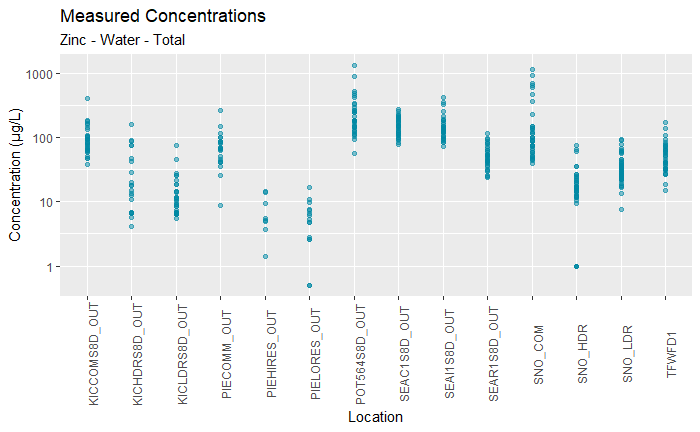

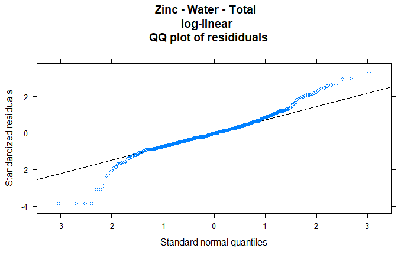

|  | vif |
| --- | --- |
| impervious | 9.29 |
| change_year_index | 9.26 |
| nighttime_lights | 3.99 |
| roadDensity | 3.79 |
| LU_ratio | 2.64 |
| logPopulation | 2.61 |

```
Linear mixed model fit by REML ['lmerMod']
Formula: concentration ~ roadDensity + (1 | Location)
   Data: df.coc

REML criterion at convergence: 3141

Scaled residuals:
   Min     1Q Median     3Q    Max
-3.124 -0.474 -0.107  0.175  5.633

Random effects:
 Groups   Name        Variance Std.Dev.
 Location (Intercept) 47.5     6.89
 Residual             70.5     8.40
Number of obs: 438, groups:  Location, 14

Fixed effects:
            Estimate Std. Error t value
(Intercept)    20.30       2.31    8.80
roadDensity    15.11       2.74    5.52

Correlation of Fixed Effects:
            (Intr)
roadDensity 0.574
Linear mixed model fit by REML ['lmerMod']
Formula: log(concentration) ~ roadDensity + (1 | Location)
   Data: df.coc

REML criterion at convergence: 932

Scaled residuals:
   Min     1Q Median     3Q    Max
-5.397 -0.532 -0.001  0.552  3.051

Random effects:
 Groups   Name        Variance Std.Dev.
 Location (Intercept) 0.313    0.559
 Residual             0.444    0.667
Number of obs: 438, groups:  Location, 14

Fixed effects:
            Estimate Std. Error t value
(Intercept)    2.559      0.187   13.68
roadDensity    1.263      0.222    5.69

Correlation of Fixed Effects:
            (Intr)
roadDensity 0.574
```

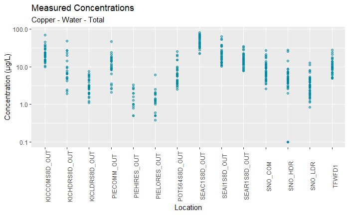

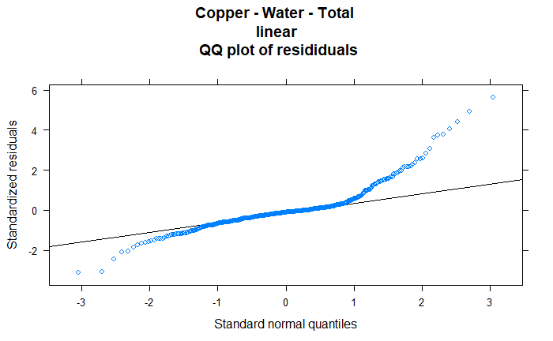

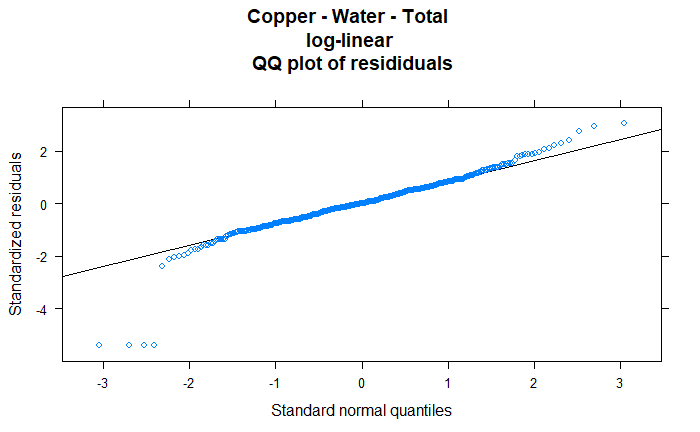

```r
show_results(2)
```

## Nitrite-Nitrate

|  | vif |
| --- | --- |
| impervious | 9.27 |
| change_year_index | 9.24 |
| nighttime_lights | 3.98 |
| roadDensity | 3.79 |
| LU_ratio | 2.63 |
| logPopulation | 2.60 |

```
Linear mixed model fit by REML ['lmerMod']
Formula: concentration ~ (1 | Location)
   Data: df.coc

REML criterion at convergence: 6108

Scaled residuals:
   Min     1Q Median     3Q    Max
-2.944 -0.408 -0.154  0.239  6.027

Random effects:
 Groups   Name        Variance Std.Dev.
 Location (Intercept) 143431   379
 Residual             185115   430
Number of obs: 406, groups:  Location, 14

Fixed effects:
            Estimate Std. Error t value
(Intercept)      480        104    4.63
Linear mixed model fit by REML ['lmerMod']
Formula: log(concentration) ~ (1 | Location)
   Data: df.coc

REML criterion at convergence: 963

Scaled residuals:
   Min     1Q Median     3Q    Max
-3.181 -0.615 -0.017  0.591  3.238

Random effects:
 Groups   Name        Variance Std.Dev.
 Location (Intercept) 0.571    0.755
 Residual             0.558    0.747
Number of obs: 406, groups:  Location, 14

Fixed effects:
            Estimate Std. Error t value
(Intercept)    5.689      0.206    27.6
```

[output not shown]

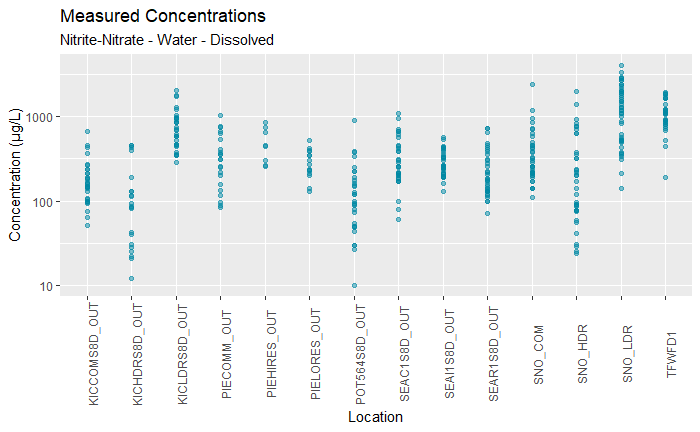

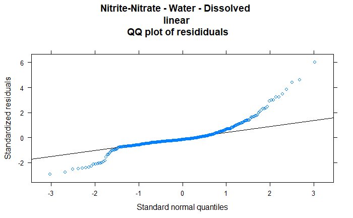

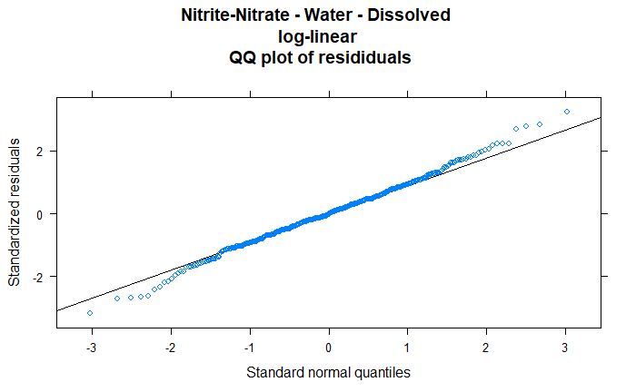

```r
show_results(3)
```

## Lead

|  | vif |
| --- | --- |
| impervious | 9.22 |
| change_year_index | 9.00 |
| nighttime_lights | 3.99 |
| roadDensity | 3.63 |
| logPopulation | 2.67 |
| LU_ratio | 2.63 |

```
Linear mixed model fit by REML ['lmerMod']
Formula: concentration ~ logPopulation + roadDensity + (1 | Location)
   Data: df.coc

REML criterion at convergence: 3233

Scaled residuals:
   Min     1Q Median     3Q    Max
-1.342 -0.453 -0.105  0.026  9.890

Random effects:
 Groups   Name        Variance Std.Dev.
 Location (Intercept)  19.6     4.43
 Residual             132.5    11.51
Number of obs: 417, groups:  Location, 14

Fixed effects:
              Estimate Std. Error t value
(Intercept)      13.48       1.65    8.19
logPopulation    -4.93       1.55   -3.17
roadDensity      11.77       2.66    4.43

Correlation of Fixed Effects:
            (Intr) lgPplt
logPopulatn -0.247
roadDensity  0.561 -0.684
Linear mixed model fit by REML ['lmerMod']
Formula: log(concentration) ~ logPopulation + roadDensity + (1 | Location)
   Data: df.coc

REML criterion at convergence: 1077

Scaled residuals:
   Min     1Q Median     3Q    Max
-3.732 -0.627 -0.016  0.577  3.301

Random effects:
 Groups   Name        Variance Std.Dev.
 Location (Intercept) 0.858    0.926
 Residual             0.689    0.830
Number of obs: 417, groups:  Location, 14

Fixed effects:
              Estimate Std. Error t value
(Intercept)      2.039      0.317    6.44
logPopulation   -0.764      0.298   -2.56
roadDensity      2.129      0.500    4.26

Correlation of Fixed Effects:
            (Intr) lgPplt
logPopulatn -0.247
roadDensity  0.574 -0.683
```

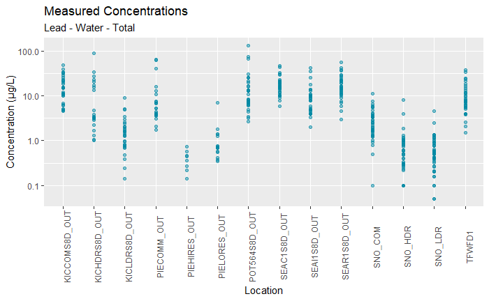

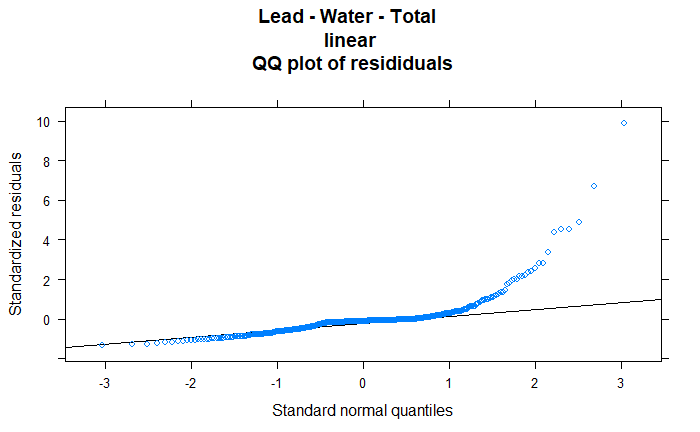

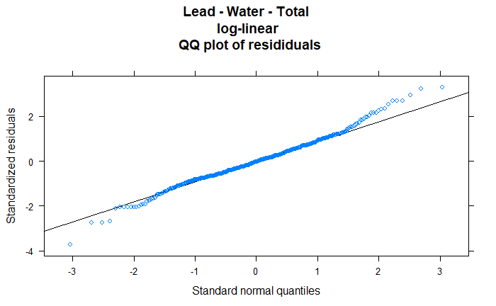

```r
show_results(4)
```

## Total Phosphorus

|  | vif |
| --- | --- |
| impervious | 9.27 |
| change_year_index | 9.25 |
| nighttime_lights | 3.98 |
| roadDensity | 3.78 |
| LU_ratio | 2.64 |
| logPopulation | 2.60 |

```
Linear mixed model fit by REML ['lmerMod']
Formula: concentration ~ roadDensity + (1 | Location)
   Data: df.coc

REML criterion at convergence: 5118

Scaled residuals:
   Min     1Q Median     3Q    Max
-1.922 -0.524 -0.213  0.278  7.274

Random effects:
 Groups   Name        Variance Std.Dev.
 Location (Intercept) 3852     62.1
 Residual             9811     99.1
Number of obs: 424, groups:  Location, 14

Fixed effects:
            Estimate Std. Error t value
(Intercept)    183.0       21.1    8.66
roadDensity     88.3       25.1    3.52

Correlation of Fixed Effects:
            (Intr)
roadDensity 0.572
Linear mixed model fit by REML ['lmerMod']
Formula: log(concentration) ~ roadDensity + (1 | Location)
   Data: df.coc

REML criterion at convergence: 905

Scaled residuals:
   Min     1Q Median     3Q    Max
-3.637 -0.669  0.003  0.673  3.338

Random effects:
 Groups   Name        Variance Std.Dev.
 Location (Intercept) 0.257    0.507
 Residual             0.449    0.670
Number of obs: 424, groups:  Location, 14

Fixed effects:
            Estimate Std. Error t value
(Intercept)    4.875      0.171   28.57
roadDensity    0.708      0.203    3.49

Correlation of Fixed Effects:
            (Intr)
roadDensity 0.574
```

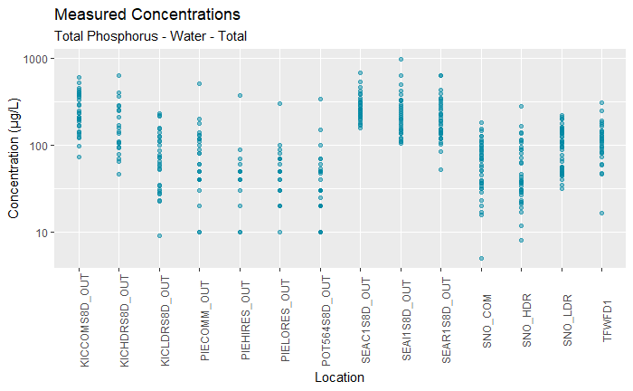

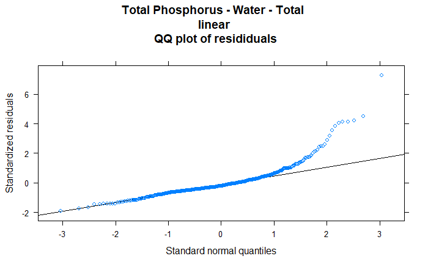

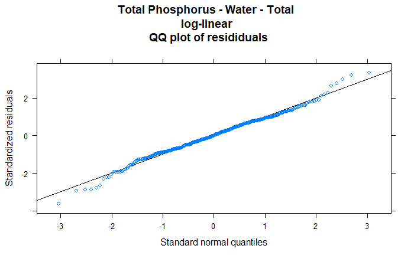

```r
show_results(5)
```

## Total Suspended Solids

|  | vif |
| --- | --- |
| impervious | 9.27 |
| change_year_index | 9.20 |
| nighttime_lights | 3.98 |
| roadDensity | 3.77 |
| LU_ratio | 2.64 |
| logPopulation | 2.64 |

```
Linear mixed model fit by REML ['lmerMod']
Formula: concentration ~ roadDensity + (1 | Location)
   Data: df.coc

REML criterion at convergence: 10253

Scaled residuals:
   Min     1Q Median     3Q    Max
-2.071 -0.457 -0.266  0.048  6.526

Random effects:
 Groups   Name        Variance Std.Dev.
 Location (Intercept) 6.76e+08 26004
 Residual             3.26e+09 57092
Number of obs: 415, groups:  Location, 14

Fixed effects:
            Estimate Std. Error t value
(Intercept)    64942       9143    7.10
roadDensity    28652      10909    2.63

Correlation of Fixed Effects:
            (Intr)
roadDensity 0.569
Linear mixed model fit by REML ['lmerMod']
Formula: log(concentration) ~ roadDensity + (1 | Location)
   Data: df.coc

REML criterion at convergence: 1234

Scaled residuals:
   Min     1Q Median     3Q    Max
-3.196 -0.584  0.016  0.557  3.276

Random effects:
 Groups   Name        Variance Std.Dev.
 Location (Intercept) 0.263    0.513
 Residual             1.064    1.031
Number of obs: 415, groups:  Location, 14

Fixed effects:
            Estimate Std. Error t value
(Intercept)   10.553      0.178   59.13
roadDensity    0.883      0.213    4.15

Correlation of Fixed Effects:
            (Intr)
roadDensity 0.570
```

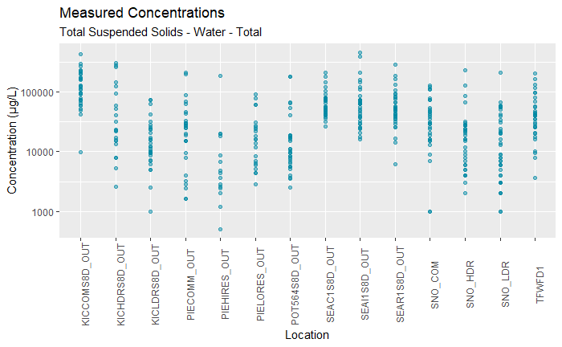

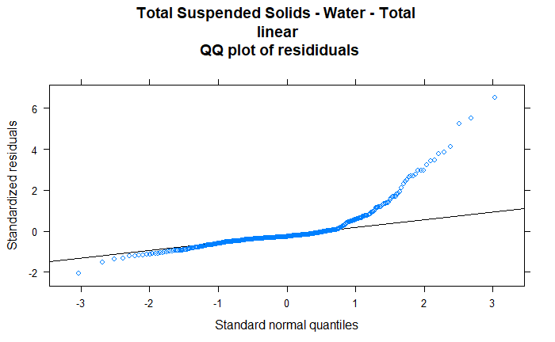

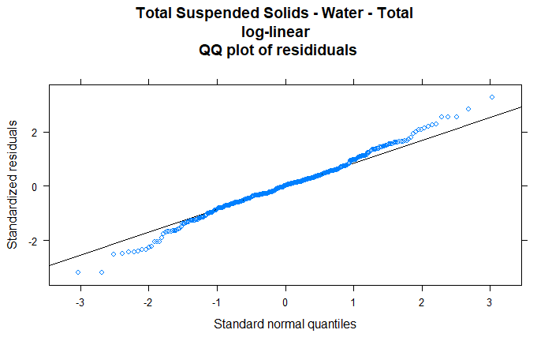

```r
show_results(6)
```

## Total Phthalate

|  | vif |
| --- | --- |
| impervious | 9.21 |
| change_year_index | 9.04 |
| nighttime_lights | 3.99 |
| roadDensity | 3.65 |
| logPopulation | 2.66 |
| LU_ratio | 2.63 |

```
Linear mixed model fit by REML ['lmerMod']
Formula: concentration ~ change_year_index + impervious + (1 | Location)
   Data: df.coc

REML criterion at convergence: 2333

Scaled residuals:
   Min     1Q Median     3Q    Max
-1.501 -0.305 -0.150 -0.003  9.027

Random effects:
 Groups   Name        Variance Std.Dev.
 Location (Intercept)  2.06    1.44
 Residual             16.21    4.03
Number of obs: 412, groups:  Location, 14

Fixed effects:
                  Estimate Std. Error t value
(Intercept)          2.239      0.524    4.27
change_year_index   -2.551      1.099   -2.32
impervious           3.167      1.044    3.03

Correlation of Fixed Effects:
            (Intr) chng__
chng_yr_ndx  0.546
impervious  -0.478 -0.911
Linear mixed model fit by REML ['lmerMod']
Formula: log(concentration) ~ (1 | Location)
   Data: df.coc

REML criterion at convergence: 1008

Scaled residuals:
   Min     1Q Median     3Q    Max
-3.095 -0.717 -0.114  0.485  4.008

Random effects:
 Groups   Name        Variance Std.Dev.
 Location (Intercept) 0.580    0.762
 Residual             0.604    0.777
Number of obs: 412, groups:  Location, 14

Fixed effects:
            Estimate Std. Error t value
(Intercept)    0.418      0.208    2.01
```

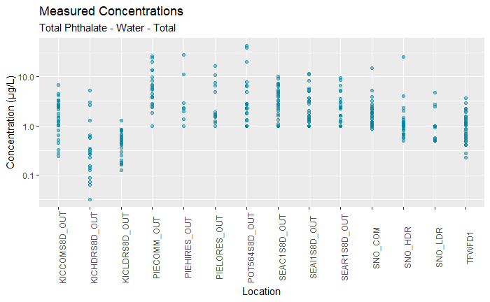

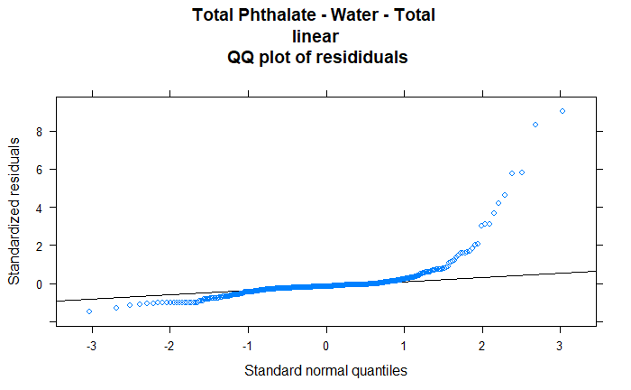

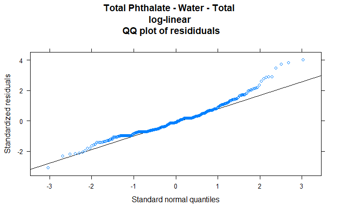

```r
show_results(7)
```

## Total PAH

|  | vif |
| --- | --- |
| impervious | 9.22 |
| change_year_index | 9.07 |
| nighttime_lights | 3.99 |
| roadDensity | 3.68 |
| logPopulation | 2.65 |
| LU_ratio | 2.63 |

```
Linear mixed model fit by REML ['lmerMod']
Formula: concentration ~ (1 | Location)
   Data: df.coc

REML criterion at convergence: 1267

Scaled residuals:
   Min     1Q Median     3Q    Max
-1.648 -0.311 -0.159  0.016  9.223

Random effects:
 Groups   Name        Variance Std.Dev.
 Location (Intercept) 0.271    0.521
 Residual             1.182    1.087
Number of obs: 412, groups:  Location, 14

Fixed effects:
            Estimate Std. Error t value
(Intercept)    0.592      0.151    3.93
Linear mixed model fit by REML ['lmerMod']
Formula: log(concentration) ~ (1 | Location)
   Data: df.coc

REML criterion at convergence: 1193

Scaled residuals:
   Min     1Q Median     3Q    Max
-3.676 -0.448 -0.183  0.542  4.240

Random effects:
 Groups   Name        Variance Std.Dev.
 Location (Intercept) 0.566    0.752
 Residual             0.960    0.980
Number of obs: 412, groups:  Location, 14

Fixed effects:
            Estimate Std. Error t value
(Intercept)   -1.417      0.208   -6.82
```

[output not shown]

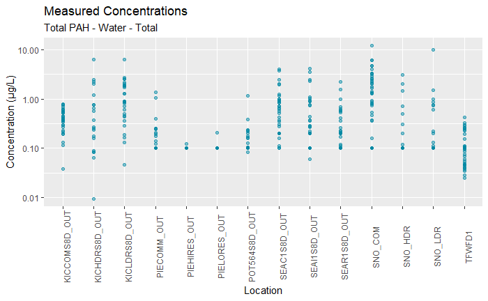

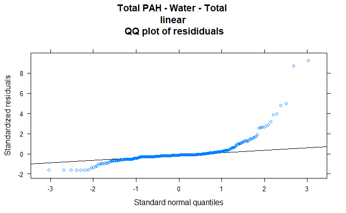

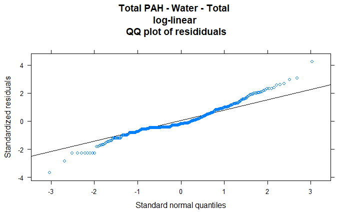

```r
show_results(8)
```

## CPAH

|  | vif |
| --- | --- |
| impervious | 9.19 |
| change_year_index | 8.91 |
| nighttime_lights | 4.00 |
| roadDensity | 3.56 |
| logPopulation | 2.70 |
| LU_ratio | 2.64 |

```
Linear mixed model fit by REML ['lmerMod']
Formula: concentration ~ (1 | Location)
   Data: df.coc

REML criterion at convergence: -528

Scaled residuals:
   Min     1Q Median     3Q    Max
-1.064 -0.266 -0.122 -0.046 10.387

Random effects:
 Groups   Name        Variance Std.Dev.
 Location (Intercept) 0.00242  0.0492
 Residual             0.01512  0.1230
Number of obs: 412, groups:  Location, 14

Fixed effects:
            Estimate Std. Error t value
(Intercept)   0.1164     0.0147    7.94
Linear mixed model fit by REML ['lmerMod']
Formula: log(concentration) ~ (1 | Location)
   Data: df.coc

REML criterion at convergence: 856

Scaled residuals:
   Min     1Q Median     3Q    Max
-3.461 -0.274 -0.056  0.129  4.487

Random effects:
 Groups   Name        Variance Std.Dev.
 Location (Intercept) 0.589    0.768
 Residual             0.412    0.642
Number of obs: 412, groups:  Location, 14

Fixed effects:
            Estimate Std. Error t value
(Intercept)   -2.518      0.208   -12.1
```

[figure not shown]

[figure not shown]

[figure not shown]

```r
show_results(9)
```

## HPAH

|  | vif |
| --- | --- |
| impervious | 9.19 |
| change_year_index | 8.90 |
| nighttime_lights | 4.00 |
| roadDensity | 3.55 |
| logPopulation | 2.71 |
| LU_ratio | 2.65 |

```
Linear mixed model fit by REML ['lmerMod']
Formula: concentration ~ logPopulation + roadDensity + (1 | Location)
   Data: df.coc

REML criterion at convergence: 757

Scaled residuals:
   Min     1Q Median     3Q    Max
-1.493 -0.248 -0.119  0.064 11.596

Random effects:
 Groups   Name        Variance Std.Dev.
 Location (Intercept) 0.0346   0.186
 Residual             0.3454   0.588
Number of obs: 412, groups:  Location, 14

Fixed effects:
              Estimate Std. Error t value
(Intercept)     0.1854     0.0721    2.57
logPopulation   0.2016     0.0679    2.97
roadDensity    -0.2976     0.1172   -2.54

Correlation of Fixed Effects:
            (Intr) lgPplt
logPopulatn -0.248
roadDensity  0.557 -0.683
Linear mixed model fit by REML ['lmerMod']
Formula: log(concentration) ~ (1 | Location)
   Data: df.coc

REML criterion at convergence: 1162

Scaled residuals:
   Min     1Q Median     3Q    Max
-3.548 -0.362 -0.128  0.249  4.158

Random effects:
 Groups   Name        Variance Std.Dev.
 Location (Intercept) 0.497    0.705
 Residual             0.892    0.944
Number of obs: 412, groups:  Location, 14

Fixed effects:
            Estimate Std. Error t value
(Intercept)   -2.140      0.195     -11
```

[figure not shown]

[figure not shown]

[figure not shown]

```r
show_results(10)
```

|  | vif |
| --- | --- |
| impervious | 9.26 |
| change_year_index | 8.69 |
| nighttime_lights | 4.00 |
| roadDensity | 3.35 |
| logPopulation | 2.80 |
| LU_ratio | 2.73 |

[output not shown]

[figure not shown]

```r
show_results(12)
```